# User Guide: `bulktrends`

Example usage of the `bulktrends` package (version 0.1.3).

## Set-up

`bulktrends` can be installed from it’s [GitHub repository](https://github.com/jbrowell/bulktrends/) using

```r
devtools::install_github("jbrowell/bulktrends")
```

Once installed, load the package and set the path to where we are storing data.

```r
library(bulktrends)
data_directory <- "path/to/my_data/"
```

Parallel computation is supported in `bulktrends` using on the [`future` framework](https://future.futureverse.org/). Its use is optional but recommended. To use parallel computation, simply set a “plan”. NB: This is currently unreliable, see [Issue #45](https://github.com/jbrowell/bulktrends/issues/45).

```r
future::plan("sequential")
```

To view progress bars, ask `progressr` to handle them.

```r
progressr::handlers(global = TRUE)
```

## Monthly UK Trade Info Data

### Load UK Trade Info Bulk Data Files

This package has been developed to work with HMRC Monthly Import data. For more details, see the package [README](https://github.com/jbrowell/bulktrends/). We can use it to download monthly trade data from the UK Trade Info and load either a single file or multiple files or all of the files in a directory (and subdirectories). This can take a while for multiple years of data, so it is recommended to save and load this data as a `.gz` file.

```r
download_uktradeinfo_bulk(
  dest_dir = file.path(data_directory,"imports/"),
  type = "imports",
  overwrite = FALSE
)
imports <- read_uktradeinfo(path = file.path(data_directory,"imports/"))
fwrite(imports, file = file.path(data_directory,"imports.gz"))
# imports <- fread(file.path(data_directory,"imports.gz"))
```

Alternatively, to update an existing dataset, simply download the latest data using `download_uktradeinfo_bulk()` and then update your dataset using `update_uktradeinfo()`. This function compares the existing dataset with the latest data downloaded and updates it by adding new rows and removing any rows that are no longer present in the latest data. Finally, save the updated dataset as a `.gz` file.

```r
update_uktradeinfo(
  existing = imports,
  path = file.path(data_directory,"imports")
)
fwrite(imports, file = file.path(data_directory,"imports.gz"))
```

```r
head(imports)
```

```
   PERREF  TYPE MONTHAC  COMCODE   SITC COD_SEQ COD_ALPHA PORT_SEQ PORT_CODE
    <int> <int>   <int>   <char> <char>   <int>    <char>    <int>    <char>
1: 201601     2  202507 01------  00---       1        FR        0       ZZZ
2: 201601     2  202507 01------  00---       3        NL        0       ZZZ
3: 201601     2  202507 01------  00---       4        DE        0       ZZZ
4: 201601     2  202507 01------  00---       5        IT        0       ZZZ
5: 201601     2  202507 01------  00---       7        IE        0       ZZZ
6: 201601     2  202507 01------  00---       8        DK        0       ZZZ
   COO_SEQ COO_ALPHA MODE_OF_TRANSPORT STAT_VALUE NET_MASS    SUMM_UNIT
     <int>    <char>             <int>      <num>    <num>       <char>
1:      NA                          NA     298531     2091 000000000022
2:      NA                          NA     319270    20318 000000000000
3:      NA                          NA        555       25 000000000000
4:      NA                          NA       5033      258 000000000000
5:      NA                          NA    1332312   406697 000000795057
6:      NA                          NA      37035     7805 000000000289
   SUPRESSION   FLOW REC_TYPE DATE_START   DATE_END
        <int> <char>    <int>     <IDat>     <IDat>
1:          0    imp        0 2016-01-01 2016-01-31
2:          0    imp        0 2016-01-01 2016-01-31
3:          0    imp        0 2016-01-01 2016-01-31
4:          0    imp        0 2016-01-01 2016-01-31
5:          0    imp        0 2016-01-01 2016-01-31
6:          0    imp        0 2016-01-01 2016-01-31
```

#### Things to be aware of

- Country of origin reporting changes from 2022 onward, individual EU countries are specified where previously they were not. There is therefore a large increase in volume (number or rows) of import data (see [methodology and quality report](https://www.gov.uk/government/statistics/overseas-trade-statistics-methodologies/overseas-trade-in-goods-statistics-methodology-and-quality-report--3#data-sources) for more information on the data).
- Low value Trade EU: Imports via port code QVV only report chapter of `COMCODE` and do not include `NET_MASS`.

### Request Data from UK Trade Data API

Download look-up tables, e.g. for commodity codes and ports, and save, or load if already available.

```r
Commodity <- uktrades_request(endpoint = "Commodity")$value
```

```r
head(Commodity)
```

```
  CommodityId Cn8Code Hs2Code Hs4Code Hs6Code
1           0      00    <NA>    <NA>    <NA>
2           1      01      01    <NA>    <NA>
3           2      02      02    <NA>    <NA>
4           3      03      03    <NA>    <NA>
5           4      04      04    <NA>    <NA>
6           5      05      05    <NA>    <NA>
                                                                                                    Hs2Description
1                                                                                                             <NA>
2                                                                                                     Live animals
3                                                                                       Meat and edible meat offal
4                                                   Fish and crustaceans, molluscs and other aquatic invertebrates
5 Dairy produce; birds' eggs; natural honey; edible products of animal origin, not elsewhere specified or included
6                                                    Products of animal origin not elsewhere specified or included
  Hs4Description Hs6Description SitcCommodityCode Cn8LongDescription
1           <NA>           <NA>                 0                  -
2           <NA>           <NA>                 0                  -
3           <NA>           <NA>                 0                  -
4           <NA>           <NA>                 0                  -
5           <NA>           <NA>                 0                  -
6           <NA>           <NA>                 0                  -
```

### Quick Visualisation

The `comcode_plot()` function produces time plots of imports by various measures included in import data, including mass, value (£) and volume (number of imports).

Here are some examples:

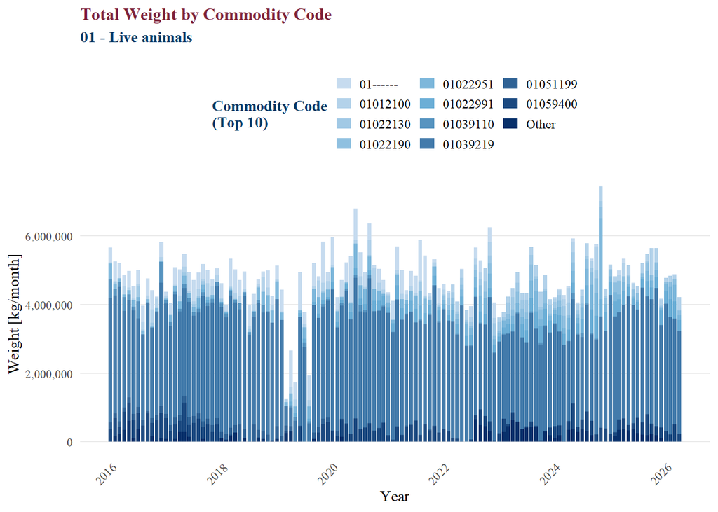

```r
comcode_plot(imports, "01", comcode_lookup=Commodity)
```

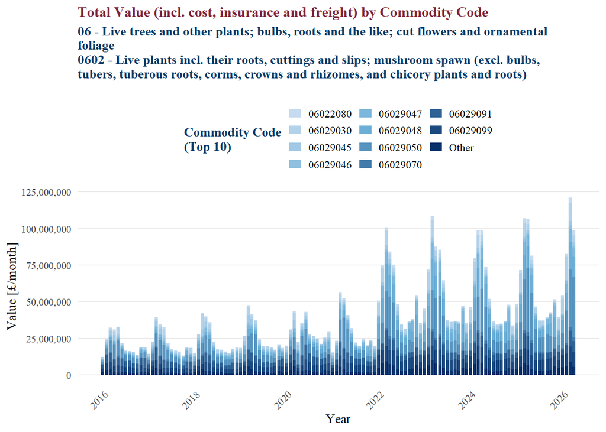

```r
comcode_plot(imports, "0602", variable="STAT_VALUE", comcode_lookup=Commodity)
```

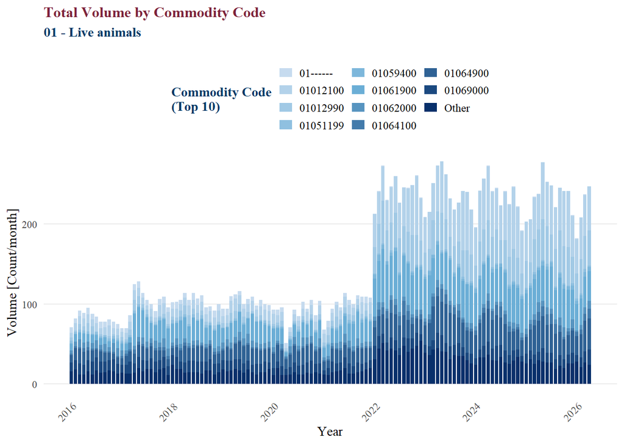

```r
comcode_plot(imports, "01", variable="volume",comcode_lookup = Commodity)
```

- Hierarchical classification of a given commodity code

```r
comcode_description("01012990", Commodity)
```

```
Hierarchical Description for Code: 01012990
---------------------------------------------
Chapter (Hs2):           01  —  Live animals
Heading (Hs4):           0101  —  Live horses, asses, mules and hinnies
Subheading (Hs6):        010129  —  Live horses (excl. pure-bred for breeding)
Commodity code (Cn8):    01012990  —  Live horses (excl. for slaughter, pure-bred for breeding)
---------------------------------------------
```

```r
comcode_description("08039010", Commodity)
```

```
Hierarchical Description for Code: 08039010
---------------------------------------------
Chapter (Hs2):           08  —  Edible fruit and nuts; peel of citrus fruits or melons
Heading (Hs4):           0803  —  Bananas, incl. plantains, fresh or dried
Subheading (Hs6):        080390  —  Fresh or dried bananas (excl. plantains)
Commodity code (Cn8):    08039010  —  Bananas, fresh (excl. plantains)
---------------------------------------------
```

```r
comcode_description("16041428", Commodity)
```

```
Hierarchical Description for Code: 16041428
---------------------------------------------
Chapter (Hs2):           16  —  Preparations of meat, fish or crustaceans, molluscs or other aquatic invertebrates
Heading (Hs4):           1604  —  Prepared or preserved fish; caviar and caviar substitutes prepared from fish eggs
Subheading (Hs6):        160414  —  Prepared or preserved tunas, skipjack and Atlantic bonito, whole or in pieces (excl. minced)
Commodity code (Cn8):    16041428  —  Prepared or preserved skipjack, whole or in pieces (excl. minced, fillets known as "loins" and such products in vegetable oil)
---------------------------------------------
```

### Filter by commodity groups

`bulktrends` includes useful groupings of commodity codes, such as plants and animals relevant for Sanitary and Phytosanitary Controls (SPS). An object called `comcode_groups` is included in `bulktrends` and loaded along with the package. Warning: `comcode_groups` does not include any suppressed codes, e.g. “01——”, take care when using.

```r
head(imports[COMCODE %in% comcode_groups$animal_SPS])
```

```
   PERREF  TYPE MONTHAC  COMCODE   SITC COD_SEQ COD_ALPHA PORT_SEQ PORT_CODE
    <int> <int>   <int>   <char> <char>   <int>    <char>    <int>    <char>
1: 201601     1  202507 01012100  00150       1        FR        0       ZZZ
2: 201601     1  202507 01012100  00150       5        IT        0       ZZZ
3: 201601     1  202507 01012100  00150       7        IE        0       ZZZ
4: 201601     1  202507 01022130  00111       7        IE        0       ZZZ
5: 201601     1  202507 01022921  00119       7        IE        0       ZZZ
6: 201601     1  202507 01022949  00119       4        DE        0       ZZZ
   COO_SEQ COO_ALPHA MODE_OF_TRANSPORT STAT_VALUE NET_MASS    SUMM_UNIT
     <int>    <char>             <int>      <num>    <num>       <char>
1:      NA                          NA     502526     3282 000000000007
2:      NA                          NA         57     2386 000000000005
3:      NA                          NA    3813813     8337 000000000018
4:      NA                          NA       1252      600 000000000001
5:      NA                          NA     989810    99680 000000000917
6:      NA                          NA     369744    69200 000000000346
   SUPRESSION   FLOW REC_TYPE DATE_START   DATE_END
        <int> <char>    <int>     <IDat>     <IDat>
1:          0    imp        0 2016-01-01 2016-01-31
2:          0    imp        0 2016-01-01 2016-01-31
3:          0    imp        0 2016-01-01 2016-01-31
4:          0    imp        0 2016-01-01 2016-01-31
5:          0    imp        0 2016-01-01 2016-01-31
6:          0    imp        0 2016-01-01 2016-01-31
```

### Time series extraction

Time series can be extracted for any single or multiple sets of commodity codes. The function can optionally group the data by any available variable, for example `PORT_CODE` for port location and `COO_ALPHA` for country of origin, or a combination of grouping columns.

When `return_list = TRUE`, the time series are returned separately for each code or combination of code and group. Alternatively, a combined output consisting of the grouping columns, date column, and quantity is returned.

```r
extract_ts(imports,
           response_col = "NET_MASS",
           code = c("01", "02"),
           return_list = TRUE)
```

```
$`01`
       code DATE_START NET_MASS
     <char>     <IDat>    <num>
  1:     01 2016-01-01  5919012
  2:     01 2016-02-01  5247215
  3:     01 2016-03-01  5208386
  4:     01 2016-04-01  4848818
  5:     01 2016-05-01  4967345
 ---
120:     01 2025-12-01  4164730
121:     01 2026-01-01  4943986
122:     01 2026-02-01  4991467
123:     01 2026-03-01  5180213
124:     01 2026-04-01  4536106

$`02`
       code DATE_START  NET_MASS
     <char>     <IDat>     <num>
  1:     02 2016-01-01 122969590
  2:     02 2016-02-01 124771052
  3:     02 2016-03-01 137218464
  4:     02 2016-04-01 126007906
  5:     02 2016-05-01 130221154
 ---
120:     02 2025-12-01 121477258
121:     02 2026-01-01 118535952
122:     02 2026-02-01 113772528
123:     02 2026-03-01 125584930
124:     02 2026-04-01 119815020
```

```r
extract_ts(
  imports,
  response_col = "NET_MASS",
  code = c("01", "02", "03"),
  group_by = c("PORT_CODE"),
  return_list = FALSE
)
```

```
         code PORT_CODE DATE_START NET_MASS
       <char>    <char>     <IDat>    <num>
    1:     01       ZZZ 2016-01-01  5910884
    2:     01       ZZZ 2016-02-01  5238176
    3:     01       ZZZ 2016-03-01  5186663
    4:     01       ZZZ 2016-04-01  4782732
    5:     01       ZZZ 2016-05-01  4929350
   ---
19340:     03       GLW 2025-12-01       NA
19341:     03       GLW 2026-01-01       NA
19342:     03       GLW 2026-02-01       NA
19343:     03       GLW 2026-03-01       NA
19344:     03       GLW 2026-04-01       NA
```

```r
extract_ts(
  imports,
  response_col = "volume",
  code = "01",
  group_by = c("PORT_CODE", "COO_ALPHA"),
  return_list = FALSE
)
```

```
         code PORT_CODE COO_ALPHA DATE_START volume
       <char>    <char>    <char>     <IDat>  <int>
    1:     01       ZZZ           2016-01-01     44
    2:     01       ZZZ           2016-02-01     49
    3:     01       ZZZ           2016-03-01     46
    4:     01       ZZZ           2016-04-01     50
    5:     01       ZZZ           2016-05-01     51
   ---
85432:     01       ZLC        EG 2025-12-01     NA
85433:     01       ZLC        EG 2026-01-01     NA
85434:     01       ZLC        EG 2026-02-01     NA
85435:     01       ZLC        EG 2026-03-01     NA
85436:     01       ZLC        EG 2026-04-01      1
```

### Anomaly detection: individual

The anomaly detection workflow considers two types of anomalies; structural breaks and temporary outliers.

For a given commodity code and quantity, (i) `extract_ts` extracts a list of time series by summing all commodities with the specified codes by time period, (ii) `select_best_model` automatically finds an optimal regression model from a pool of candidate models of base models and models with structural breaks, and (iii) `detect_outliers` specifically detects temporary outliers (“AO” additive outliers and “TC” temporary changes) using an outlier detection algorithm.

In this workflow, structural break detection is performed within `select_best_model()` by using `break_detection = TRUE`. If any break is identified, the detected break information is stored in the `break_entry` output.

When `return_tso = TRUE` in `detect_outliers`, the full output object returned by tsoutliers::tso() is retained, allowing users to inspect the detected outliers, model diagnostics, fitted regressors, and temporary outlier effects in detail.

```r
ts_data <- extract_ts(imports, "01", response_col="NET_MASS")

selected_model <- select_best_model(ts_data, response_col = "NET_MASS", break_detection = TRUE)

detected_anomaly <- detect_outliers(data = selected_model$data,
                    response_col= "NET_MASS",
                    scale_ts = TRUE,
                    return_tso = TRUE,
                    xreg = model.matrix(selected_model$formula, data = selected_model$data),
                    tso_params = list(cval= 4))

print(selected_model$break_entry)
```

```
     type   ind       time
   <char> <num>     <IDat>
1:     SB    38 2019-02-01
2:     SB    57 2020-09-01
```

```r
print(detected_anomaly)
```

```
$data
       code DATE_START NET_MASS linear_trend day_of_year  annual_sin
     <char>     <IDat>    <num>        <num>       <int>       <num>
  1:     01 2016-01-01  5919012     2016.000           1  0.01721336
  2:     01 2016-02-01  5247215     2016.085          32  0.52341561
  3:     01 2016-03-01  5208386     2016.164          61  0.86745635
  4:     01 2016-04-01  4848818     2016.249          92  0.99991666
  5:     01 2016-05-01  4967345     2016.331         122  0.86314213
 ---
120:     01 2025-12-01  4164730     2025.915         335 -0.49377555
121:     01 2026-01-01  4943986     2026.000           1  0.01721336
122:     01 2026-02-01  4991467     2026.085          32  0.52341561
123:     01 2026-03-01  5180213     2026.162          60  0.85876396
124:     01 2026-04-01  4536106     2026.247          91  0.99999074
       annual_cos segments          TC1   AO1   AO2
            <num>   <fctr>        <num> <num> <num>
  1:  0.999851839 segment1 0.000000e+00     0     0
  2:  0.852077521 segment1 0.000000e+00     0     0
  3:  0.497513289 segment1 0.000000e+00     0     0
  4: -0.012910296 segment1 0.000000e+00     0     0
  5: -0.504961055 segment1 0.000000e+00     0     0
 ---
120:  0.869589389 segment3 2.837535e-13     0     0
121:  0.999851839 segment3 1.986275e-13     0     0
122:  0.852077521 segment3 1.390392e-13     0     0
123:  0.512371412 segment3 9.732745e-14     0     0
124:  0.004303538 segment3 6.812922e-14     0     0

$outliers
  type ind time   coefhat     tstat
1   TC  39   39 -4.144315 -4.061376
2   AO  44   44 -3.440421 -4.773205
3   AO 107  107  3.322622  5.081012

$tso
Series: structure(c(1.25679138776745, 0.442340518677348, 0.395266309063581,  -0.0406547654529598, 0.103041050635296, -0.424735895518584, 0.136222979531966,  -0.811223533763233, 0.0746915356437097, -0.568920287322783, -0.800788865805116,  1.12461528992457, -0.628828398993552, -0.968264862211538, 0.24…
Regression with ARIMA(0,0,0) errors

Coefficients:
      (Intercept)  linear_trend  annual_sin  annual_cos  segmentssegment2
```

[output cut: 8 more lines]

```
      annual_sin:segmentssegment3  annual_cos:segmentssegment2
                          -0.3053                      -0.2719
s.e.                       0.1877                       0.2698
      annual_cos:segmentssegment3     TC39     AO44   AO107
                          -0.3079  -4.1443  -3.4404  3.3226
s.e.                       0.1821   1.0204   0.7208  0.6539

sigma^2 = 0.4599:  log likelihood = -119.79
AIC=271.58   AICc=276.67   BIC=316.71

Outliers:
  type ind time coefhat  tstat
1   TC  39   39  -4.144 -4.061
2   AO  44   44  -3.440 -4.773
3   AO 107  107   3.323  5.081
```

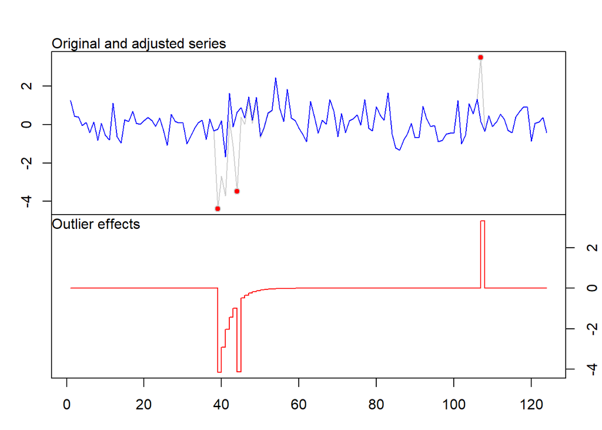

```r
plot.tsoutliers(detected_anomaly$tso)
```

### Anomaly detection: large-scale

Detecting anomalies can be performed for a list of commodity codes using the `detect_anomalies()` function. The data to be supplied can either be lists of single time series or a `tsibble` data frame, a time-series table format that supports later analysis.

The function returns (i) a table of all detected anomalies (breaks and outliers) across all codes, (ii) a `data.table` for each code containing the original time series, the time index, and the associated anomaly covariates and, (iii) the final model formula for each time series.

```r
hs2_codes <- unique(substr(imports$COMCODE, 1,2))

ts_list <- extract_ts(imports, code = hs2_codes[1:5], return_list = T)

hs2_anomalies <- detect_anomalies(data = ts_list,
                                  response_col = "NET_MASS",
                                  scale_ts = TRUE,
                                  verbose = FALSE,
                                  tso_params = list(cval = 4))

print(hs2_anomalies$outliers)
```

```
      type   ind       time   coefhat     tstat     id anomaly_type
    <fctr> <num>     <Date>     <num>     <num> <char>       <char>
 1:     SB    38 2019-02-01        NA        NA     01        Break
 2:     TC    39 2019-03-01 -4.144315 -4.061376     01      Outlier
 3:     AO    44 2019-08-01 -3.440421 -4.773205     01      Outlier
 4:     SB    57 2020-09-01        NA        NA     01        Break
 5:     AO   107 2024-11-01  3.322622  5.081012     01      Outlier
 6:     SB    51 2020-03-01        NA        NA     02        Break
 7:     TC    61 2021-01-01 -2.663593 -5.351327     02      Outlier
 8:     TC    37 2019-01-01  2.833507  4.748622     03      Outlier
 9:     SB    72 2021-12-01        NA        NA     03        Break
10:     SB    39 2019-03-01        NA        NA     04        Break
11:     SB    79 2022-07-01        NA        NA     04        Break
12:     SB    98 2024-02-01        NA        NA     05        Break
```

#### Tsibble conversion and anomaly detection

To perform large-scale anomaly detection using data in tsibble format, the function `uktrade_tsibble()` can be used to convert a `data.table` into a `tsibble` data frame. This allows for automatic classification and relevant aggregation according to hierarchies and groups specified. Once in a tsibble format, the data can be used in detect_anomalies() as follows:

```r
tsibble_data <- uktrade_tsibble(
  response_col = "NET_MASS",
  data = imports[DATE_START >= "2024-01-01"],
  comcode_level = c("HS2", "HS4"),
  group_by = "category"
)

hs2_anomalies <- detect_anomalies(data = tsibble_data[tsibble_data[["HS2"]] == "01",],
                                  response_col = "NET_MASS",
                                  scale_ts = TRUE,
                                  verbose = FALSE,
                                  tso_params = list(cval = 4, types = c("AO", "TC")))

print(hs2_anomalies$outliers)
```

```
      type   ind       time                           id anomaly_type
    <fctr> <num>     <Date>                       <char>       <char>
 1:     SB     5 2024-05-01               01|Animal|0101        Break
 2:     SB     9 2024-09-01               01|Animal|0101        Break
 3:     SB    16 2025-04-01               01|Animal|0101        Break
 4:     SB    21 2025-09-01               01|Animal|0101        Break
 5:     SB     5 2024-05-01               01|Animal|0102        Break
 6:     SB    10 2024-10-01               01|Animal|0102        Break
 7:     SB    14 2025-02-01               01|Animal|0102        Break
 8:     SB    20 2025-08-01               01|Animal|0102        Break
 9:     SB    24 2025-12-01               01|Animal|0102        Break
10:     SB    12 2024-12-01               01|Animal|0103        Break
11:     SB     5 2024-05-01               01|Animal|0105        Break
12:     SB     4 2024-04-01               01|Animal|0106        Break
13:     SB    12 2024-12-01               01|Animal|0106        Break
```

[output cut: 95 more lines]

## Daily IPAFFS Data

### Load IPAFFS Data Files

The Food Standards Agency (FSA) makes some Import of Products, Animals, Food and Feed System (IPAFFS) data public which we can also analyse with `bulktrends`. The data files contain daily data of high-risk products of animal origin and high-risk food of non-animal origin imported into the United Kingdom via approved designated ports (see the [FSA](https://www.food.gov.uk/our-work/imports-intelligence-hub) website for more information). We can load a single csv file or all csv files in a directory (and subdirectories) using `read_ipaffs()`.

```r
imports_ipaffs <- read_ipaffs(path = paste0(data_directory,"imports_fsa_ipaffs"))
```

For consistency, some column names have been standardised. For example, (i) date columns include `DATE_START` and `DATE_END`, (ii) all variations of net weight columns across `.csv` files have been renamed as `NET_MASS` and (iii) all variations of commodity code columns are renamed as `COMCODE`.

```r
head(imports_ipaffs[,c(1:4,9,10,55,56,43,17)])
```

```
   CountryOfOrigin DATE_START NotificationStatus  COMCODE IdentityCheckResult
            <char>     <Date>             <char>   <char>              <char>
1:            <NA>       <NA>               <NA>   020230                <NA>
2:            <NA>       <NA>               <NA> 16041428                <NA>
3:            <NA>       <NA>               <NA> 03048700                <NA>
4:            <NA>       <NA>               <NA> 16042090                <NA>
5:            <NA>       <NA>               <NA>   020714                <NA>
6:            <NA>       <NA>               <NA> 16042050                <NA>
   PhysicalCheckYesOrNo Commodityintendedfor Acceptablefortransfer
                 <char>               <char>                <char>
1:                 <NA>                 <NA>                  <NA>
2:                 <NA>                 <NA>                  <NA>
3:                 <NA>                 <NA>                  <NA>
4:                 <NA>                 <NA>                  <NA>
5:                 <NA>                 <NA>                  <NA>
6:                 <NA>                 <NA>                  <NA>
   NotAcceptable2 DATE_END
           <char>   <Date>
1:           <NA>     <NA>
2:           <NA>     <NA>
3:           <NA>     <NA>
4:           <NA>     <NA>
5:           <NA>     <NA>
6:           <NA>     <NA>
```

### Data Visualisation

The `comcode_plot()` function can be used to also visualise daily time series. For the IPAFFS data, we can currently view `NET_MASS` and `volume` as follows:

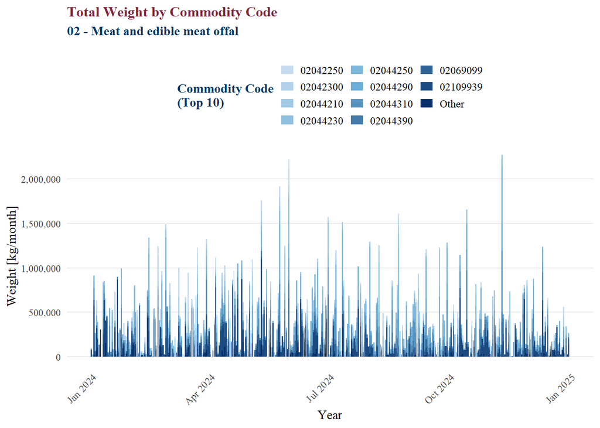

```r
comcode_plot(imports_ipaffs[DATE_START>="2024-01-01"],
             code =  "02",
             variable = "NET_MASS",
             comcode_lookup=Commodity)
```

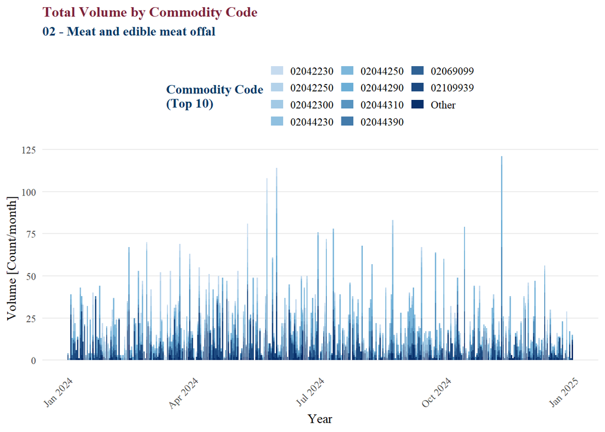

```r
comcode_plot(imports_ipaffs[DATE_START>="2024-01-01"],
             code =  "02",
             variable = "volume",
             comcode_lookup=Commodity)
```

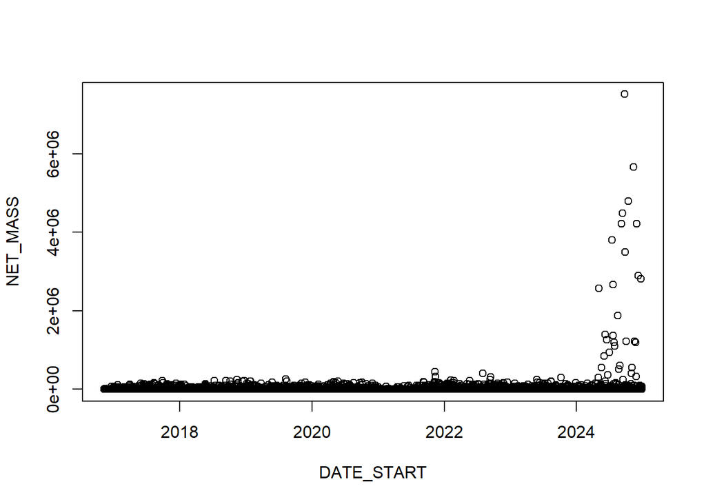

```r
ts_data <- extract_ts(imports_ipaffs,
                      code = "15",
                      response_col = "NET_MASS",
                      date_col = "DATE_START",
                      fill_missing = 0,
                      freq = "day")

plot(NET_MASS ~ DATE_START, data = ts_data)
```

### Anomaly detection: individual

The anomaly detection procedure described using the monthly HMRC data can also be applied to the daily IPAFFS data. This involves using the same functions, such as, `extract_ts` to obtain the time series of a given commodity code, `select_best_model` to identify structural breaks and select an appropriate model from the same set of candidate models, and using `detect_outliers` to identify the various types of temporary outliers.

```r
ts_data <- extract_ts(imports_ipaffs[DATE_START>="2023-01-01"],
                      code = "07",
                      response_col = "NET_MASS",
                      date_col = "DATE_START",
                      fill_missing=0)

selected_model <- select_best_model(ts_data, response_col = "NET_MASS", break_detection = TRUE)

detected_anomaly <- detect_outliers(data = selected_model$data,
                    response_col= "NET_MASS",
                    scale_ts = FALSE,
                    return_tso = TRUE,
                    xreg = model.matrix(selected_model$formula, data = selected_model$data),
                    tso_params = list(cval= 4))

print(selected_model$break_entry)
```

[output not shown]

```r
print(detected_anomaly)
```

```
$data
       code DATE_START NET_MASS linear_trend day_of_year    annual_sin
     <char>     <Date>    <num>        <num>       <int>         <num>
  1:     07 2023-01-01 25696.35     2023.000           1  1.721336e-02
  2:     07 2023-01-02 45436.36     2023.003           2  3.442161e-02
  3:     07 2023-01-03 49642.30     2023.005           3  5.161967e-02
  4:     07 2023-01-04 63523.20     2023.008           4  6.880243e-02
  5:     07 2023-01-05 37401.26     2023.011           5  8.596480e-02
 ---
727:     07 2024-12-27 46578.50     2024.986         362 -5.161967e-02
728:     07 2024-12-28 55447.37     2024.989         363 -3.442161e-02
729:     07 2024-12-29 47393.65     2024.992         364 -1.721336e-02
730:     07 2024-12-30 48780.25     2024.995         365  6.432571e-16
731:     07 2024-12-31 62017.95     2024.997         366  1.721336e-02
     annual_cos day_of_week        holiday is_holiday   AO1   AO2   AO3
          <num>      <char>         <char>     <lgcl> <num> <num> <num>
  1:  0.9998518      Sunday           <NA>      FALSE     0     0     0
  2:  0.9994074      Monday New Year’s Day       TRUE     0     0     0
  3:  0.9986668     Tuesday    2nd January       TRUE     0     0     0
  4:  0.9976303   Wednesday           <NA>      FALSE     0     0     0
  5:  0.9962982    Thursday           <NA>      FALSE     0     0     0
 ---
727:  0.9986668      Friday           <NA>      FALSE     0     0     0
728:  0.9994074    Saturday           <NA>      FALSE     0     0     0
729:  0.9998518      Sunday           <NA>      FALSE     0     0     0
730:  1.0000000      Monday           <NA>      FALSE     0     0     0
731:  0.9998518     Tuesday           <NA>      FALSE     0     0     0
              TC1   AO4   AO5   AO6   AO7   AO8   AO9  AO10  AO11  AO12  AO13
            <num> <num> <num> <num> <num> <num> <num> <num> <num> <num> <num>
  1: 0.000000e+00     0     0     0     0     0     0     0     0     0     0
  2: 0.000000e+00     0     0     0     0     0     0     0     0     0     0
  3: 0.000000e+00     0     0     0     0     0     0     0     0     0     0
  4: 0.000000e+00     0     0     0     0     0     0     0     0     0     0
  5: 0.000000e+00     0     0     0     0     0     0     0     0     0     0
 ---
727: 1.074912e-97     0     0     0     0     0     0     0     0     0     0
728: 7.524386e-98     0     0     0     0     0     0     0     0     0     0
729: 5.267070e-98     0     0     0     0     0     0     0     0     0     0
730: 3.686949e-98     0     0     0     0     0     0     0     0     0     0
731: 2.580865e-98     0     0     0     0     0     0     0     0     0     0
```

[output cut: 43 more lines]

```
   type ind time coefhat tstat
1    AO  55   55   94492 4.470
2    AO  71   71  183768 8.693
3    AO  86   86   99402 4.702
4    TC 101  101   62991 4.131
5    AO 109  109   90472 4.273
6    AO 186  186  115300 5.452
7    AO 256  256  117730 5.567
8    AO 270  270  129399 6.118
9    AO 277  277  124685 5.895
10   AO 293  293   99191 4.693
11   AO 301  301  120142 5.682
12   AO 465  465   95485 4.514
13   AO 648  648   91612 4.332
14   AO 695  695  109507 5.181
```

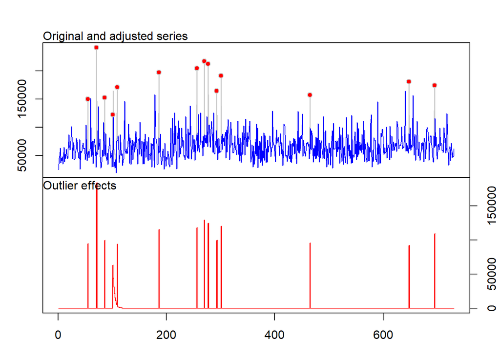

```r
plot.tsoutliers(detected_anomaly$tso)
```

### Anomaly detection: large-scale

Here is also an example of using the `detect_anomalies()` function to a selected group of commodity codes from the IPAFFS dataset for large-scale anomaly detection. Based on IPAFFS data availability, the function can skip time series that are too short or incomplete. A verbose option is also provided, when set to `TRUE`, progress messages are displayed to help track execution steps.

Similarly, the function works with both lists of time series and `tsibble` data format, and also returns (i) a table of all detected anomalies (breaks and outliers) across all codes, (ii) a `data.table` for each code containing the original time series, the time index, and the associated anomaly covariates and, (iii) the final model formula for each time series.

```r
hs2_codes <- sort(unique(substr(imports_ipaffs$COMCODE, 1,2)))

netmass_list <- extract_ts(imports_ipaffs[DATE_START>="2023-01-01"],
                           response_col = "NET_MASS",
                           code = hs2_codes[1:5],
                           return_list = T)

hs2_anomalies_netmass <- detect_anomalies(data = netmass_list,
                                  response_col = "NET_MASS",
                                  scale_ts = TRUE,
                                  verbose = FALSE,
                                  tso_params = list(cval= 4))


volume_list <- extract_ts(imports_ipaffs[DATE_START>="2023-01-01"],
                          response_col = "volume",
                          code = hs2_codes[1:5],
                          return_list = T)

hs2_anomalies_volume <- detect_anomalies(data = volume_list,
                                  response_col = "volume",
                                  scale_ts = TRUE,
                                  verbose = FALSE,
                                  tso_params = list(cval= 4))

head(hs2_anomalies_netmass$outliers)
head(hs2_anomalies_volume$outliers)
```

Note: The above anomaly detection procedures for daily data work but can take a while to run so their output has been excluded.